# Machine Learning Final Project

awmillar

Tuesday, March 01, 2016

### 1 .Purpose

The Purpose of this report is to try to predict a classification (data set variable ‘classe’) for the quality of dumbbell exercise using predictors related to acelerometer data. These data are gathered from 4 points,

1. a belt around the waist of the exerciser
2. at the forearm of the exerciser,
3. on the dumbbell the exerciser is using, and
4. on the arm of the exerciser

The individuals doing the exercises created the data by doing exercises correctly (with ‘classe’ labeled ‘A’) and then incorrectly in 4 different ways (with ‘classe’ labels ‘B’,‘C’, ‘D’, and ‘E’)

### 2. Narrowing down the data

Since we are allowed to use any of the 160 variables, narrowing them down will be essential. The first step to take is to understand the training variables:

```
##        X            user_name    raw_timestamp_part_1 raw_timestamp_part_2
##  Min.   :    1   adelmo  :3892   Min.   :1.322e+09    Min.   :   294
##  1st Qu.: 4906   carlitos:3112   1st Qu.:1.323e+09    1st Qu.:252912
##  Median : 9812   charles :3536   Median :1.323e+09    Median :496380
##  Mean   : 9812   eurico  :3070   Mean   :1.323e+09    Mean   :500656
##  3rd Qu.:14717   jeremy  :3402   3rd Qu.:1.323e+09    3rd Qu.:751891
##  Max.   :19622   pedro   :2610   Max.   :1.323e+09    Max.   :998801
##
##           cvtd_timestamp  new_window    num_window      roll_belt
##  28/11/2011 14:14: 1498   no :19216   Min.   :  1.0   Min.   :-28.90
##  05/12/2011 11:24: 1497   yes:  406   1st Qu.:222.0   1st Qu.:  1.10
##  30/11/2011 17:11: 1440               Median :424.0   Median :113.00
##  05/12/2011 11:25: 1425               Mean   :430.6   Mean   : 64.41
##  02/12/2011 14:57: 1380               3rd Qu.:644.0   3rd Qu.:123.00
##  02/12/2011 13:34: 1375               Max.   :864.0   Max.   :162.00
##  (Other)         :11007
##    pitch_belt          yaw_belt       total_accel_belt kurtosis_roll_belt
##  Min.   :-55.8000   Min.   :-180.00   Min.   : 0.00             :19216
##  1st Qu.:  1.7600   1st Qu.: -88.30   1st Qu.: 3.00    #DIV/0!  :   10
##  Median :  5.2800   Median : -13.00   Median :17.00    -1.908453:    2
##  Mean   :  0.3053   Mean   : -11.21   Mean   :11.31    -0.016850:    1
##  3rd Qu.: 14.9000   3rd Qu.:  12.90   3rd Qu.:18.00    -0.021024:    1
##  Max.   : 60.3000   Max.   : 179.00   Max.   :29.00    -0.025513:    1
##                                                        (Other)  :  391
##  kurtosis_picth_belt kurtosis_yaw_belt skewness_roll_belt
##           :19216            :19216              :19216
##  #DIV/0!  :   32     #DIV/0!:  406     #DIV/0!  :    9
##  47.000000:    4                       0.000000 :    4
##  -0.150950:    3                       0.422463 :    2
##  -0.684748:    3                       -0.003095:    1
##  -1.750749:    3                       -0.010002:    1
##  (Other)  :  361                       (Other)  :  389
##  skewness_roll_belt.1 skewness_yaw_belt max_roll_belt     max_picth_belt
##           :19216             :19216     Min.   :-94.300   Min.   : 3.00
##  #DIV/0!  :   32      #DIV/0!:  406     1st Qu.:-88.000   1st Qu.: 5.00
##  0.000000 :    4                        Median : -5.100   Median :18.00
##  -2.156553:    3                        Mean   : -6.667   Mean   :12.92
##  -3.072669:    3                        3rd Qu.: 18.500   3rd Qu.:19.00
##  -6.324555:    3                        Max.   :180.000   Max.   :30.00
##  (Other)  :  361                        NA's   :19216     NA's   :19216
```

[output cut: 313 more lines]

```
##  Min.   :-446.00   Min.   :-1280.0   Min.   :-896.0   Min.   :-973.0
##  1st Qu.:-182.00   1st Qu.: -616.0   1st Qu.:   2.0   1st Qu.: 191.0
##  Median : -39.00   Median : -378.0   Median : 591.0   Median : 511.0
##  Mean   : -55.29   Mean   : -312.6   Mean   : 380.1   Mean   : 393.6
##  3rd Qu.:  26.00   3rd Qu.:  -73.0   3rd Qu.: 737.0   3rd Qu.: 653.0
##  Max.   : 291.00   Max.   :  672.0   Max.   :1480.0   Max.   :1090.0
##
##  classe
##  A:5580
##  B:3797
##  C:3422
##  D:3216
##  E:3607
##
##
```

When a summary of the variables is performed, it becomes clear that there are many variables that have incomplete data. Variables that seem to have data for every observation are only 53 out of the 160 variables.

```
##  [1] "num_window"           "roll_belt"            "pitch_belt"
##  [4] "yaw_belt"             "total_accel_belt"     "gyros_belt_x"
##  [7] "gyros_belt_y"         "gyros_belt_z"         "accel_belt_x"
## [10] "accel_belt_y"         "accel_belt_z"         "magnet_belt_x"
## [13] "magnet_belt_y"        "magnet_belt_z"        "roll_arm"
## [16] "pitch_arm"            "yaw_arm"              "total_accel_arm"
## [19] "gyros_arm_x"          "gyros_arm_y"          "gyros_arm_z"
## [22] "accel_arm_x"          "accel_arm_y"          "accel_arm_z"
## [25] "magnet_arm_x"         "magnet_arm_y"         "magnet_arm_z"
## [28] "roll_dumbbell"        "pitch_dumbbell"       "yaw_dumbbell"
## [31] "total_accel_dumbbell" "gyros_dumbbell_x"     "gyros_dumbbell_y"
## [34] "gyros_dumbbell_z"     "accel_dumbbell_x"     "accel_dumbbell_y"
## [37] "accel_dumbbell_z"     "magnet_dumbbell_x"    "magnet_dumbbell_y"
## [40] "magnet_dumbbell_z"    "roll_forearm"         "pitch_forearm"
## [43] "yaw_forearm"          "total_accel_forearm"  "gyros_forearm_x"
## [46] "gyros_forearm_y"      "gyros_forearm_z"      "accel_forearm_x"
## [49] "accel_forearm_y"      "accel_forearm_z"      "magnet_forearm_x"
## [52] "magnet_forearm_y"     "magnet_forearm_z"     "classe"
```

With ‘classe’ being the classification we want to predict.

We also have one other constraint - **we do not know the test set ‘classe values’!** The only way to find them out is to build a model and submit the model’s prediction, and then we will only be supplied with matches ( correct predictions) so the more right are original model is, the better it will be to help us refine it. In addition, we can only query the test data 3 times.

### 3. Initial modeling.

Without doing a great deal of exploratory analysis, we need to use a method that will a) be fairly accurate, and b) provide a baseline for further predictions c) get better as we add more predictors

Based on what we know of the test data, we can see that ‘total acceleration’ values for all of the 4 measurement points are included in the subset of data that have usable values for all the observations. These variables are

total_accel_belt total_accel_arm total_accel_dumbbell total_accel_forearm

These four will be our starting point to differentiate the types of correctly or incorrectly performed exercises, since they are a short list, but they collect data at all of the acelerometer points.

In terms of the type of machine learning algorithm to perform, we will use **random forests**. This choice is because we need as much accuracy as possible. Limiting the initial model to only 4 variables to start will hopefully mitigate the constraints on memory that we have, while leaving the door open for another larger set of variables, as random forests actually works better with more variables. However, for the sake of keeping memory costs low, we will be trying to select additional variables ourselves.

```r
modelfit1<-train(classe ~ total_accel_belt + total_accel_arm + total_accel_dumbbell +total_accel_forearm ,method="rf",data=training)
pred_1<- predict(modelfit1,testing)

print(modelfit1$finalModel)
```

```
##
## Call:
##  randomForest(x = x, y = y, mtry = param$mtry)
##                Type of random forest: classification
##                      Number of trees: 500
## No. of variables tried at each split: 2
##
##         OOB estimate of  error rate: 30.34%
## Confusion matrix:
##      A    B    C    D    E class.error
## A 4488  284  398  344   66   0.1956989
## B  452 2248  508  262  327   0.4079536
## C  400  314 2263  328  117   0.3386908
## D  428  197  437 1991  163   0.3809080
## E  151  379  201  198 2678   0.2575548
```

```r
print(modelfit1)
```

```
## Random Forest
##
## 19622 samples
##   159 predictor
##     5 classes: 'A', 'B', 'C', 'D', 'E'
##
## No pre-processing
## Resampling: Bootstrapped (25 reps)
## Summary of sample sizes: 19622, 19622, 19622, 19622, 19622, 19622, ...
## Resampling results across tuning parameters:
##
##   mtry  Accuracy   Kappa      Accuracy SD  Kappa SD
##   2     0.6745428  0.5877351  0.005045188  0.006117134
##   3     0.6585321  0.5678101  0.005695894  0.007020444
##   4     0.6505090  0.5577380  0.005762438  0.007129483
##
## Accuracy was used to select the optimal model using  the largest value.
## The final value used for the model was mtry = 2.
```

```r
print(pred_1)
```

```
##  [1] A A C A A E D B A A B E B A A E A B C B
## Levels: A B C D E
```

### 4. Adding more descriptors

To start, we will take a look at of all means of each of the variables calculated for each of the 5 classifications, A through E.

```r
aggregate(dubtrain, by=list(dubtrain$classe), FUN=mean)
```

```
##   Group.1 num_window roll_belt  pitch_belt   yaw_belt total_accel_belt
## 1       A   384.6977  59.34989  0.35583871 -12.033455         10.67814
## 2       B   502.8457  65.16313 -0.01914669 -13.291030         11.13853
## 3       C   483.7434  64.81424 -1.04698714  -7.379407         11.18381
## 4       D   431.4188  60.85452  1.81800684 -17.864089         11.22917
## 5       E   374.6293  74.21647  0.50276130  -5.419947         12.67397
##   gyros_belt_x gyros_belt_y gyros_belt_z accel_belt_x accel_belt_y
## 1 -0.004922939   0.04048566   -0.1213746    -6.261290     28.94265
## 2 -0.004824862   0.04253095   -0.1347748    -4.934422     31.97603
## 3 -0.014921099   0.03949445   -0.1350994    -4.048802     31.11748
## 4 -0.014732587   0.03633396   -0.1365641    -8.279851     30.46300
## 5  0.009564735   0.03808983   -0.1305517    -4.331023     28.92515
##   accel_belt_z magnet_belt_x magnet_belt_y magnet_belt_z   roll_arm
## 1    -62.68387      57.82975      602.1978     -337.9289 -0.5660538
## 2    -73.60047      49.21991      599.3790     -336.6987 32.0088491
```

[output cut: 57 more lines]

From there, we can start to run some descriptive plots on the most promising of these:

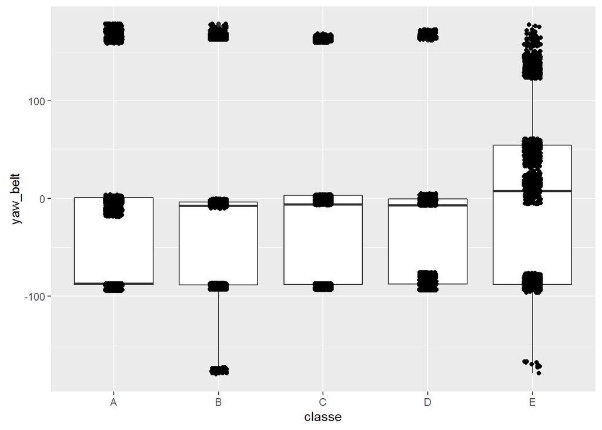

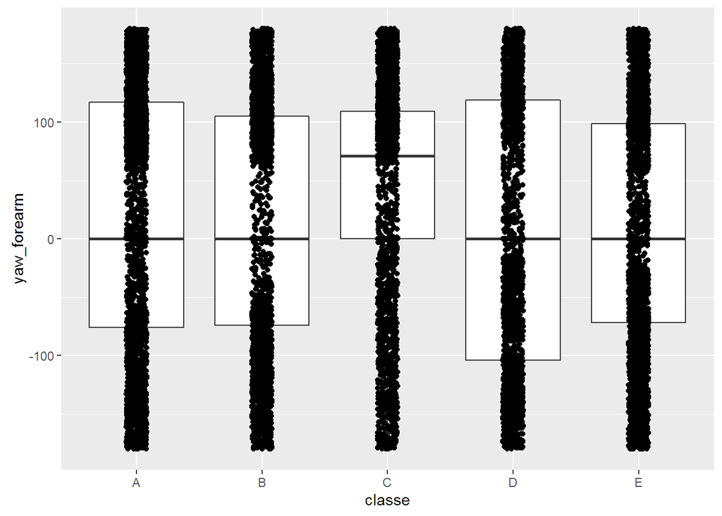

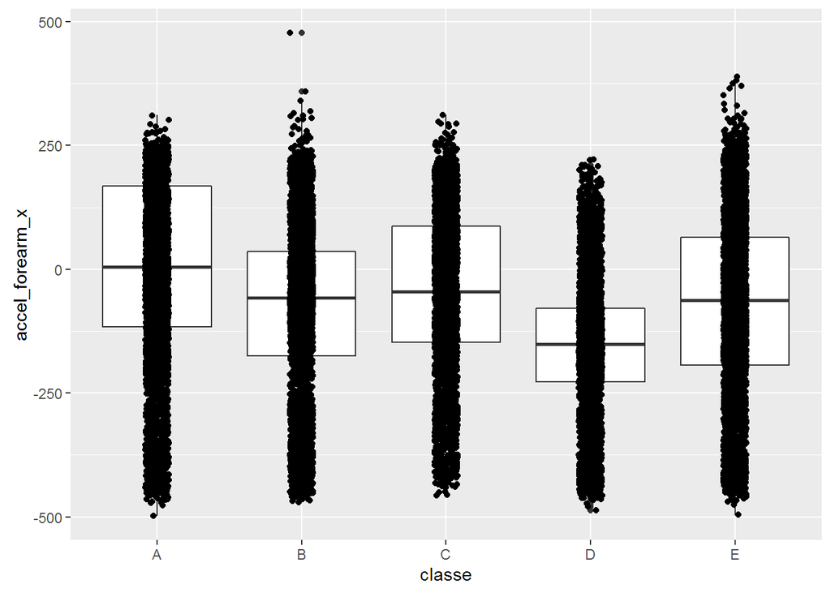

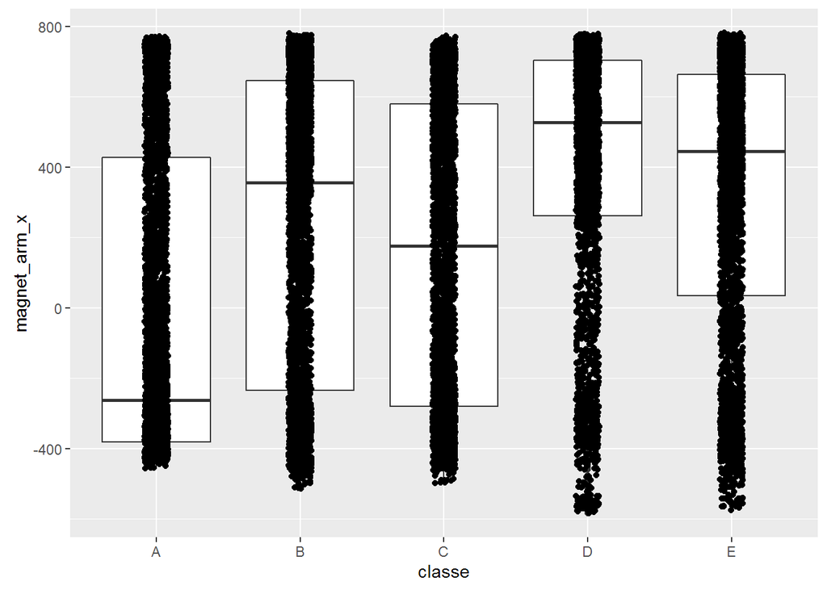

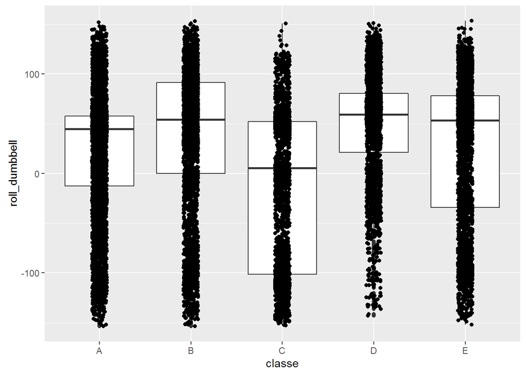

These plots give some indication that the variables “yaw_belt”, “yaw_forearm”, “accel_forearm_x”, “magnet_arm_x”, and “roll_dumbbell” show some degree of differentiation across the five classifications. Thus, by adding these to the model, it will likely be more accurate.

### 5. New model with additional predictors

We will now create a new model with the additional predictors

```r
modelfit2<-train(classe ~total_accel_belt + total_accel_arm + total_accel_dumbbell + total_accel_forearm + yaw_belt + yaw_forearm + accel_forearm_x + magnet_arm_x +roll_dumbbell ,method="rf",data=training)
pred_2<- predict(modelfit2,testing)

print(modelfit2$finalModel)
```

```
##
## Call:
##  randomForest(x = x, y = y, mtry = param$mtry)
##                Type of random forest: classification
##                      Number of trees: 500
## No. of variables tried at each split: 2
##
##         OOB estimate of  error rate: 2.54%
## Confusion matrix:
##      A    B    C    D    E class.error
## A 5511   13   29   25    2  0.01236559
## B   63 3628   86    6   14  0.04450882
## C   21   44 3323   32    2  0.02893045
## D   30    9   60 3112    5  0.03233831
## E    6   19   18   14 3550  0.01580261
```

```r
print(modelfit2)
```

```
## Random Forest
##
## 19622 samples
##   159 predictor
##     5 classes: 'A', 'B', 'C', 'D', 'E'
##
## No pre-processing
## Resampling: Bootstrapped (25 reps)
## Summary of sample sizes: 19622, 19622, 19622, 19622, 19622, 19622, ...
## Resampling results across tuning parameters:
##
##   mtry  Accuracy   Kappa      Accuracy SD  Kappa SD
##   2     0.9654558  0.9562910  0.002405597  0.003044273
##   5     0.9632705  0.9535276  0.002414229  0.003048760
##   9     0.9496224  0.9362587  0.004544249  0.005771591
##
## Accuracy was used to select the optimal model using  the largest value.
## The final value used for the model was mtry = 2.
```

```r
print(pred_2)
```

```
##  [1] C A B A A C D B A A B C B A E E A B B B
## Levels: A B C D E
```

This prediction model seems to do a better job, with an out of sample error rate of of (2.5%).

### Results

When finally put up to the true test - **the test set**, it produces only two errors out of 20. (test observations #1 and #6). Interestingly, it turns out the original model produced 5 errors, out of twenty, but did manage to predict #6 correctly, when our better model got it wrong.